# COVID-19 Survey Analysis

## **Exploratory Analysis**

### **Introduction**

We are researching the mental health statistics due to COVID-19 because of the current situation we are living in. This dataset has given us unique questions that allow us to see how people are reacting to the COVID pandemic during their daily life. From measuring the amount of time people communicate with their family/friends, rating one’s mental health from excellent to poor, and using their gender as a means of comparison this data gives us an insight on how COVID-19 has impacted our mental health. Now more than ever are we more aware of taking care of one’s mental health and we can use this data to better understand COVID’s affect on individuals.

### **Summary Information Script**

```r
One_person_excellent <- chart3 %>%
  filter(`how would you rate your health` == "(1) Excellent") %>%
  filter(`household size` == "(1) One person, I live by myself") %>%
  summarise(`household size`,`how would you rate your health`)
nrow(One_person_excellent)
```

```r
num_female_Excellent <- dataset2 %>%
  filter(gender == "(2) Female") %>%
  filter(`how would you rate your health` == "(1) Excellent")
nrow(num_female_Excellent)
```

```r
num_male_Excellent <- dataset2 %>%
  filter(gender == "(1) Male") %>%
  filter(`how would you rate your health` == "(1) Excellent")
nrow(num_male_Excellent)
```

```r
Contant_before_covid <- dataset2 %>%
  filter(`how often did you stay in touch with family/friend before covid` == "(1) Basically every day")
nrow(Contant_before_covid)
```

```r
Contact_with_family <- dataset2 %>%
  filter(`how often did you stay in touch with family/friends`== "(1) Basically every day")
nrow(Contact_with_family)
```

### **Table of Aggregated Data**

|  | how much do you trust your neighborhood | talk with neighbor in month | talk with neighbor in month before covid | how often did you stay in touch with family/friends | how often did you stay in touch with family/friend before covid | did you volunteer this month | how often did you volunteer per month before covid | how would you rate your health | household_size |
| --- | --- | --- | --- | --- | --- | --- | --- | --- | --- |
| 7500 | (2) Most | (3) A few times a month | (3) A few times a month | (2) A few times a week | (2) A few times a week | (2) No | (2) No | (2) Very good | (2) Two persons |
| 7501 | (3) Some | (3) A few times a month | (3) A few times a month | (2) A few times a week | (2) A few times a week | (2) No | (2) No | (3) Good | (1) One person, I live by myself |
| 7502 | (2) Most | (2) A few times a week | (1) Basically every day | (2) A few times a week | (3) A few times a month | (2) No | (2) No | (3) Good | (1) One person, I live by myself |
| 7503 | (4) None | (2) A few times a week | (2) A few times a week | (1) Basically every day | (1) Basically every day | (2) No | (1) Yes | (2) Very good | (2) Two persons |
| 7504 | (2) Most | (5) Not at all | (5) Not at all | (1) Basically every day | (1) Basically every day | (2) No | (2) No | (3) Good | (2) Two persons |
| 7505 | (3) Some | (2) A few times a week | (1) Basically every day | (1) Basically every day | (1) Basically every day | (2) No | (1) Yes | (2) Very good | (2) Two persons |

We decided to include this snippet of our filtered table to show the possible values and format that could appear with this certain dataset. This table displays the last few rows of the most important columns for our entire analysis. The information for each column represents an answer to the question in the column name. For example, the `household size` column contains rows of responses that list between `"One person, I live by myself"` all the way up to `"Six or more persons"`.

### **First Chart:** *Histogram of Mental Health Ratings by Gender*

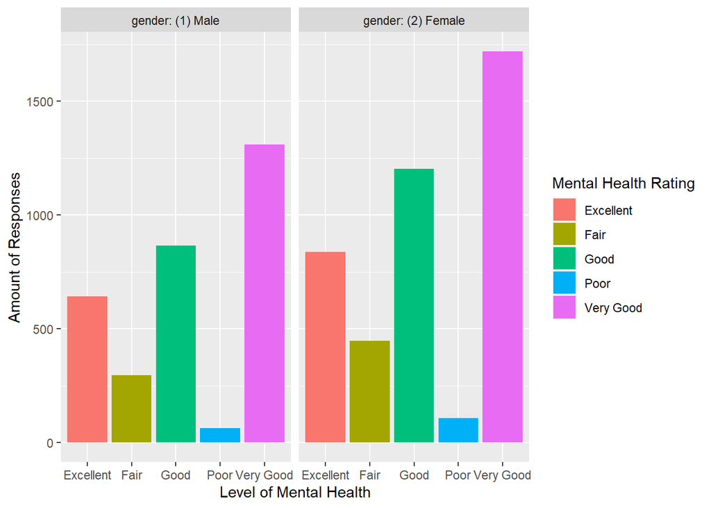

We decided to include this chart to see and showcase the similarities between each gender and their personal *ratings for their mental health*. This histogram is organized and clear in a manner that reflects a pattern of a high number of `“Very Good”` and `“Good”` ratings across both males and females. The **purpose** of this chart is to break down the data set from one question to gather insight about how males and females have viewed their level of mental health. Some **notable** observations and insights from the chart include the evidence of how most males and females rated their level of mental health as `“Very Good”`. The histogram is color-coded to more clearly highlight each possible response and the number of those responses in the data that clearly show the same order of the number of responses. For both males and females, the highest number of responses were under `“Very Good”`, then continued in the order of `“Good”`, `“Excellent”`, `“Fair”` and then both having the lowest number of responses for `“Poor”`.

### **Second Chart:** *Stacked Bar Chart of How Often People Communicated*

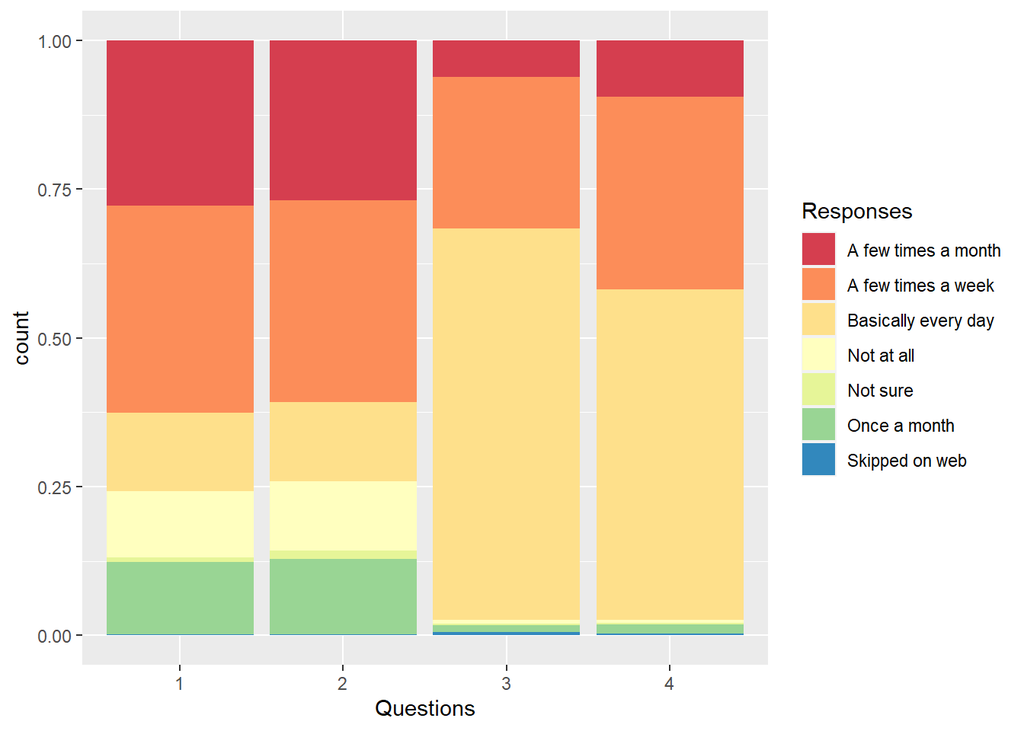

In this chart we are comparing people’s responses on how often they talked to their neighbors before and during COVID-19. `Row 1` asked the question “How often did you talk to your neighbors?” `Row 2` asks “How often did you talk to your neighbors during COVID-19?”. `Row 3` asks “How often did you stay in touch with your family and friends during quarantine?” `Row 4` asks “How often did you stay in touch with your family and friends BEFORE COVID-19?” We thought it was important to include this data because it demonstrates how more people reached out to their friends and family when the pandemic started.

An interesting observation we made was that when people talked to their family and friends `“Basically every day”` compared to the people who only talked to their family and friends `“A few times a week”`. Another observation is there was hardly any change with how often people communicated with their neighbors before or during quarantine.

### **Third Chart:** *Household Size and Mental Health Ratings*

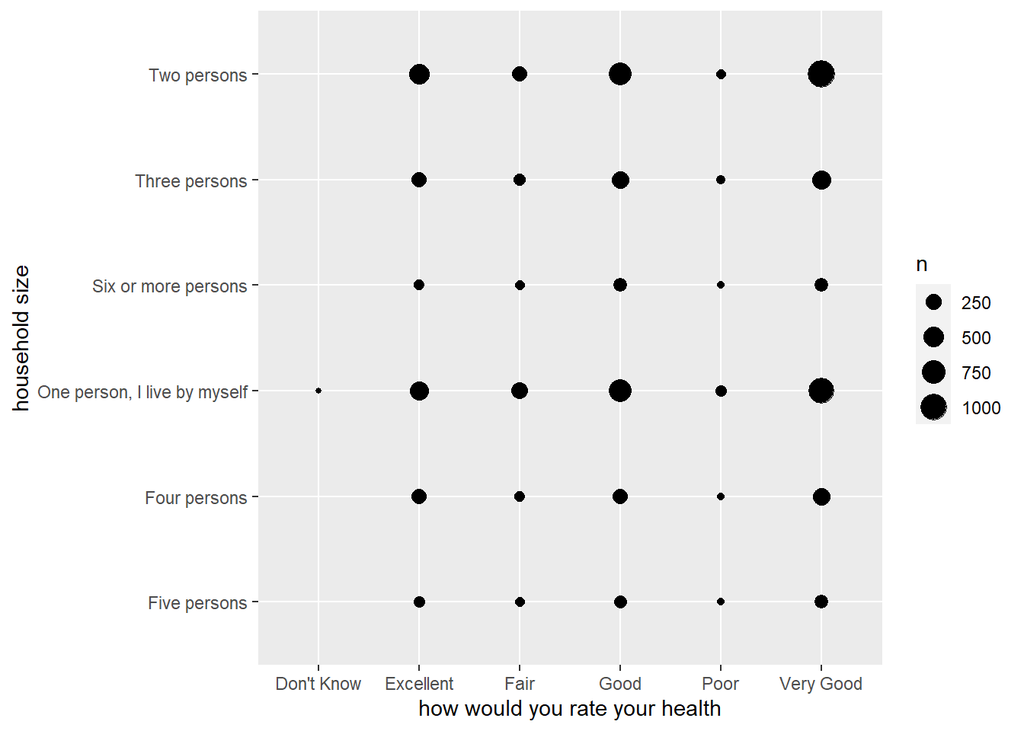

In this scatterplot we are showing how people rated their health during COVID-19 compared to the amount of people that live in a household. The scatterplot shows that the bigger the bubble is the more people that are in the category. This chart is important because it shows how much having another person in your household affects the way you are feeling mentally. Each bubble size is separated by 250, 500, 750, and 1,000 people.

From our observation the plot that had the most people was `“Two Persons”` household and they felt `“Very Good”`. The column that shows us the most clear evidence of COVID’s impact on people who live by themselves is the people who feel `“Poor”` column. As the number of people in a household increases the less people say that they feel `“Poor”`.